# Exploratory Data Analysis using Python - A Case Study

### Analyzing the Netflix Original Films & IMDB Scores Dataset

*A basic exploratory data analysis on a small dataset as a part of the Jovian's Data Analysis with Python: Zero to Pandas course.*

The aim of this project is to get familiarized with the concepts of data analytics with the help of python libraries such as pandas, numpy, matplotlib and seaborn.

```python
!pip install jovian --upgrade --quiet
```

### Importing the relevant libraries

```python
import jovian
import os
import pandas as pd
import numpy as np
import seaborn as sns
import matplotlib.pyplot as plt
%matplotlib inline
from urllib.request import urlretrieve
```

```python
# Execute this to save new versions of the notebook
jovian.commit(project="project1")
```

```
[jovian] Updating notebook "alinatabish/netflix-case-study" on https://jovian.ai
[jovian] Committed successfully! https://jovian.ai/alinatabish/netflix-case-study
```

```
'https://jovian.ai/alinatabish/netflix-case-study'
```

### Importing And Prepping The Data For Analysis

The Netflix and their IMDB scores dataset has been downloaded from Kaggle. Link to dataset: www.kaggle.com/luiscorter/netflix-original-films-imdb-scores

```python
# getting absolute path till the data file
abs_path = os.getcwd()[:-15]
data_path = abs_path + "NetflixOriginals.csv"

# reading the csv into the pandas dataframe
df = pd.read_csv(data_path,encoding='Windows-1252')
```

```python
df
```

|  | Title | Genre | Premiere | Runtime | IMDB Score | Language |
| --- | --- | --- | --- | --- | --- | --- |
| 0 | Enter the Anime | Documentary | August 5, 2019 | 58 | 2.5 | English/Japanese |
| 1 | Dark Forces | Thriller | August 21, 2020 | 81 | 2.6 | Spanish |
| 2 | The App | Science fiction/Drama | December 26, 2019 | 79 | 2.6 | Italian |
| 3 | The Open House | Horror thriller | January 19, 2018 | 94 | 3.2 | English |
| 4 | Kaali Khuhi | Mystery | October 30, 2020 | 90 | 3.4 | Hindi |
| ... | ... | ... | ... | ... | ... | ... |
| 579 | Taylor Swift: Reputation Stadium Tour | Concert Film | December 31, 2018 | 125 | 8.4 | English |
| 580 | Winter on Fire: Ukraine's Fight for Freedom | Documentary | October 9, 2015 | 91 | 8.4 | English/Ukranian/Russian |
| 581 | Springsteen on Broadway | One-man show | December 16, 2018 | 153 | 8.5 | English |
| 582 | Emicida: AmarElo - It's All For Yesterday | Documentary | December 8, 2020 | 89 | 8.6 | Portuguese |
| 583 | David Attenborough: A Life on Our Planet | Documentary | October 4, 2020 | 83 | 9.0 | English |

584 rows × 6 columns

### Data Preparation And Cleaning

Prepping the data for the exploratory analysis

```python
# exploring the number of rows and columns of the dataset

df.shape # pandas shape returns a tuple representing the dimensionality of the dataframe
```

```
(584, 6)
```

We can see that this dataset is pretty small with only 6 columns and 584 rows

```python
# checking for any null values

df.isnull() # pandas isnull() function detects any missing values in the dataframe and returns a boolean indicating if the values are NA
```

|  | Title | Genre | Premiere | Runtime | IMDB Score | Language |
| --- | --- | --- | --- | --- | --- | --- |
| 0 | False | False | False | False | False | False |
| 1 | False | False | False | False | False | False |
| 2 | False | False | False | False | False | False |
| 3 | False | False | False | False | False | False |
| 4 | False | False | False | False | False | False |
| ... | ... | ... | ... | ... | ... | ... |
| 579 | False | False | False | False | False | False |
| 580 | False | False | False | False | False | False |
| 581 | False | False | False | False | False | False |
| 582 | False | False | False | False | False | False |
| 583 | False | False | False | False | False | False |

584 rows × 6 columns

```python
# checking the type of values this dataset has

df.sample(5) # pandas sample() function returns a sample of items from an axis of object
```

|  | Title | Genre | Premiere | Runtime | IMDB Score | Language |
| --- | --- | --- | --- | --- | --- | --- |
| 535 | Dick Johnson Is Dead | Documentary | October 2, 2020 | 90 | 7.5 | English |
| 468 | My Beautiful Broken Brain | Documentary | March 18, 2016 | 91 | 7.1 | English |
| 281 | Spectral | Science fiction/Action | December 9, 2016 | 108 | 6.3 | English |
| 132 | One-Way to Tomorrow | Romance | June 19, 2020 | 90 | 5.6 | Turkish |
| 338 | Nobody Knows I'm Here | Drama | June 24, 2020 | 91 | 6.5 | Spanish |

Since we might need to analyze the premiere years and months of the films in future so let's add a column for release year and release month of the films

```python
# making a copy of the original dataframe as a backup
df_copy = df.copy()
df_copy

# making a new column 'Release Year' and appending it at the end of the dataframe
df['Release Year'] = df['Premiere'].str.slice(-4) #slicing the 'Premiere' column's last 4 characters to extract the premiere year
df['Release Month'] = df['Premiere'].str.slice(0,3) #slicing the 'Premiere' column's first 3 characters to extract the premiere month

df
```

|  | Title | Genre | Premiere | Runtime | IMDB Score | Language | Release Year | Release Month |
| --- | --- | --- | --- | --- | --- | --- | --- | --- |
| 0 | Enter the Anime | Documentary | August 5, 2019 | 58 | 2.5 | English/Japanese | 2019 | Aug |
| 1 | Dark Forces | Thriller | August 21, 2020 | 81 | 2.6 | Spanish | 2020 | Aug |
| 2 | The App | Science fiction/Drama | December 26, 2019 | 79 | 2.6 | Italian | 2019 | Dec |
| 3 | The Open House | Horror thriller | January 19, 2018 | 94 | 3.2 | English | 2018 | Jan |
| 4 | Kaali Khuhi | Mystery | October 30, 2020 | 90 | 3.4 | Hindi | 2020 | Oct |
| ... | ... | ... | ... | ... | ... | ... | ... | ... |
| 579 | Taylor Swift: Reputation Stadium Tour | Concert Film | December 31, 2018 | 125 | 8.4 | English | 2018 | Dec |
| 580 | Winter on Fire: Ukraine's Fight for Freedom | Documentary | October 9, 2015 | 91 | 8.4 | English/Ukranian/Russian | 2015 | Oct |
| 581 | Springsteen on Broadway | One-man show | December 16, 2018 | 153 | 8.5 | English | 2018 | Dec |
| 582 | Emicida: AmarElo - It's All For Yesterday | Documentary | December 8, 2020 | 89 | 8.6 | Portuguese | 2020 | Dec |
| 583 | David Attenborough: A Life on Our Planet | Documentary | October 4, 2020 | 83 | 9.0 | English | 2020 | Oct |

584 rows × 8 columns

Our dataset is now prepped for the exploratory analysis. Since there were no null or incorrect values in this dataset, there was no need of cleaning the data.

### Performing Exploratory Analysis And Visualizations

Computing some statistics on the data and taking notes on some interesting insights

```python
# calculating the average of the IMDB scores of the netflix films

df_avg= df['IMDB Score'].mean() # the pandas mean() function returns return mean of the selected column

print('The overall average of all the IMDB scores of netflix films out of 10 is: ', df_avg)
```

```
The overall average of all the IMDB scores of netflix films out of 10 is:  6.27174657534246
```

Now let's see the IMDB scores of these films with the help of a histogram.

**Histogram is a graph showing the frequency distribution and often used for numeric data**

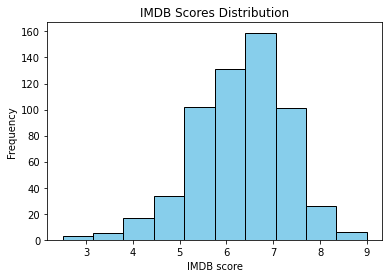

```python
plt.title("IMDB Scores Distribution") #setting the title of the plot
plt.xlabel('IMDB score') # setting the x label of the plot
plt.ylabel('Frequency') # setting the y label of the plot
plt.hist(df['IMDB Score'], color="skyblue", edgecolor='black'); # plotting the points on the histogram
```

Let's see how many different types genres of the films we have got using a bar chart

**Bar Chart displays data using rectangular bars. One axis of a bar chart measures a value, while the other axis lists variables**

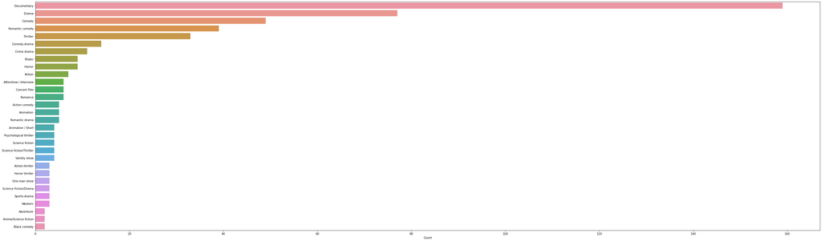

```python
# drawing the bar plot for the genre column
# grouping the dataframe by "genre" column and then counting each category and displaying first 30 genres with largest count
y=df.groupby("Genre")['Genre'].count().nlargest(30)
y
x = y.index #the index(row labels) of the dataframe

plt.figure(figsize=(50,15)) # setting the plot figure size
ax = sns.barplot(x= y, y = x) # using the seaborn's barplot method
ax.set(xlabel = 'Count')
ax.set(ylabel = '')

plt.show() # displaying the plot
```

From this we can see that most of our data is about the documentary genre.

```python
# filtering out the genres which have a film count greater than 10
genre_filter=df['Genre'].value_counts().loc[lambda x: x>10].to_frame()
genre_filter
```

|  | Genre |
| --- | --- |
| Documentary | 159 |
| Drama | 77 |
| Comedy | 49 |
| Romantic comedy | 39 |
| Thriller | 33 |
| Comedy-drama | 14 |
| Crime drama | 11 |

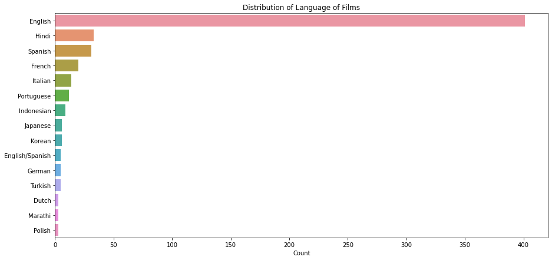

```python
# checking the count of the language of the film

lang =df.groupby('Language')['Language'].count().nlargest(15)
y=lang
x=lang.index

fig=plt.figure(figsize=(15,7))
l=sns.barplot(x=y,y=x);
l.set(title='Distribution of Language of Films', xlabel="Count", ylabel="");
```

We can see that most of films on Netflix are of English language.

Lastly, we will analyze how have the IMDB scores changed overs the years using a scatter plot

**Scatter Plot uses dots to represent values for two different numeric variables**

```python
# sorting the dataframe by ascending release years
df_sorted=df.sort_values(by="Release Year") #sort_values() function sorts the values along either axis
```

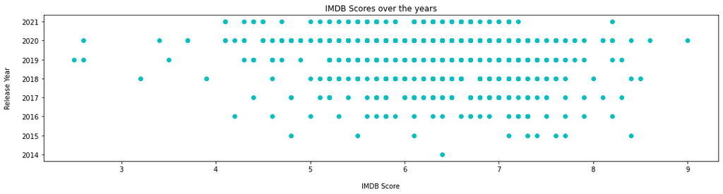

```python
year = df_sorted['Release Year']
rating=df_sorted['IMDB Score']

plt.figure(figsize=(18, 4))
plt.scatter(rating,year,c='c')
plt.xlabel("IMDB Score", labelpad=15)
plt.ylabel("Release Year", labelpad=15)
plt.title("IMDB Scores over the years");
```

We are done with our basic exploratory analysis of our data with some interesting insights noted.

Now we'll move on to the next step, asking and answering some data-driven questions about our dataset.

### Asking And Answering Questions About The Data

Let's ask some interesting questions about our data and how we can solve it using the concepts of pandas, matplotlib and seaborn.

#### Question 1:

**Which movie genres have been the most loved over the years?**

We need to answer how the genres have changed over the years and which genres have been the most loved over the years by analyzing their IMDB scores.

Let's analyze the genres of the movies over the year using a line plot.

**Line Plot is a way to display data along a number line**

Since there are about 100+ different genres, we'll only analyze a few of the common genres which have a film count of greater than 5

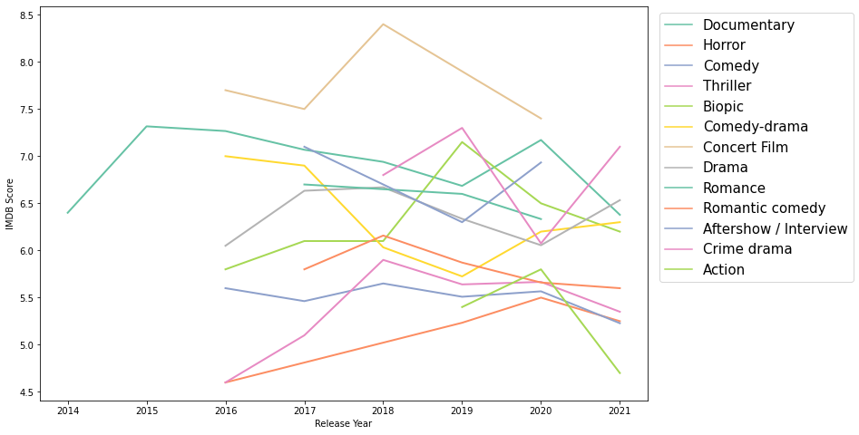

```python
# filtering out the genres which have a film count greater than 5

genre_filter=df.groupby('Genre').filter(lambda x : len(x)>5).sort_values(by="Release Year")
#the filter() method subsets the dataframe rows or columns according to the specified index labels.

# plotting the genre_filter in a line plot along with the years
g=sns.lineplot(data=genre_filter, x=genre_filter["Release Year"], y=genre_filter['IMDB Score'], hue=genre_filter["Genre"], ci=None,linewidth = 2, palette="Set2")
g.legend(loc='upper right', bbox_to_anchor=(1.35, 1), prop={'size': 15})
fig = plt.gcf()
fig.set_size_inches(12, 8)
```

The timeline graph shows the IMDB scores of each genre over the years. The top 3 genres with highest IMDB Scores are *Concert Film, Crime drama and Documentary.*

Let's see the number of films of these 3 genres have using a pie chart.

**Pie Chart represents the data in a circular graph. The entire “pie” represents 100 percent of a whole, while the pie “slices” represent portions of the whole**

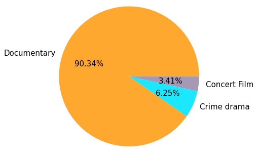

```python
#storing the top 3 genres with highest IMDB scores in a list
list_of_genre= ["Documentary", "Crime drama", "Concert Film"]

genre_list_count=[]
for i in range(0,3):
    genre_count=len(df[df['Genre'] == list_of_genre[i]])

    genre_list_count.append(genre_count) # appending the total count of each genre in the list

fig = plt.figure()
ax = fig.add_axes([0,0,1,1])
ax.axis('equal')
colorss = ['#FEA82F','#1BE7FF','#A599B5']
ax.pie(genre_list_count, labels = list_of_genre,autopct='%1.2f%%', colors=colorss, wedgeprops = {'linewidth': 3}, radius=1.2, textprops = {"fontsize":15})
plt.show()
```

#### Question 2

**Does the type of movies depend on their release month or not?**

Let's try to answer whether the type or genre of the films changed depending on the month of their release like were the Christmas movies mostly released during the month of December when Christmas is near or maybe patriotic films were usually released during the month of independence day

We will analyze the months of the movies related to America's common public holidays and celebrations such as Christmas, Halloween, Veteran's Day, Easter and others.

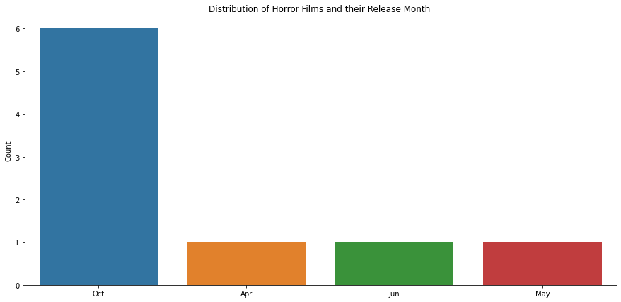

```python
# filtering out the genres related to these holidays

# analyzing the 'horror' genre
genre_horror=df[(df["Genre"] == "Horror")]
genre_horror_count=genre_horror.groupby("Release Month")["Release Month"].count().nlargest(12)

y=genre_horror_count
x=y.index

fig=plt.figure(figsize=(15,7))
l=sns.barplot(x=x,y=y);
l.set(title='Distribution of Horror Films and their Release Month ', xlabel="", ylabel="Count");
```

From this visualization we can see that most of the horror films were released during the month of October since it's the month of Halloween.

Next we'll try to observe Christmas movies. Since there is no specific genre for 'Christmas', we will filter out the movies using the 'Title' column which will contain the string 'Christmas'

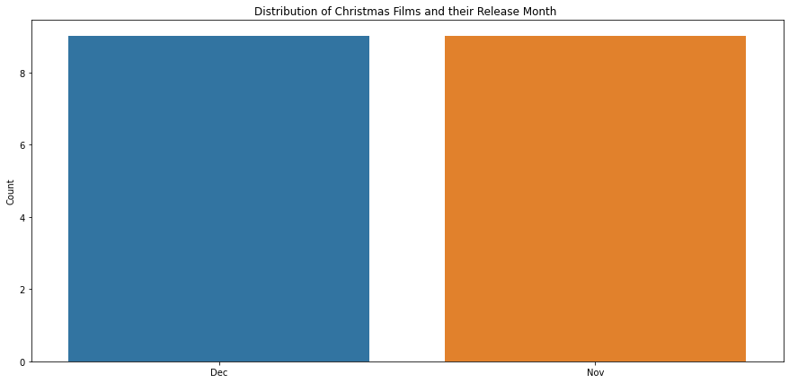

```python
#filtering out the dataframe

# Christmas movies
christmas_movies=df[df['Title'].str.contains("Christmas", case=False)]

#plotting the bar chart
christmas_count=christmas_movies.groupby("Release Month")["Release Month"].count().nlargest(12)

y=christmas_count
x=y.index

fig=plt.figure(figsize=(15,7))
l=sns.barplot(x=x,y=y);
l.set(title='Distribution of Christmas Films and their Release Month ', xlabel="", ylabel="Count");
```

Here we can see that all the Christmas movies ever released were either in the month of November and December since these months are near Christmas.

Lastly, let's observe the release months of romance movies

[figure not shown]

```python
romance_movies= df[df["Genre"].str.contains("Romance|Romantic", case=False) ]
romance_movies

#plotting bar chart
romance_count=romance_movies.groupby("Release Month")["Release Month"].count().nlargest(12)

y=romance_count
x=y.index

fig=plt.figure(figsize=(15,7))
l=sns.barplot(x=x,y=y);
l.set(title='Distribution of Christmas Films and their Release Month ', xlabel="", ylabel="Count");
```

The highest count of Romance movies were released in February since Valentine's Day is in this month.

From these visualizations, we can see that this could be a marketing tactic by the Netflix to release these films during the month of these respective celebrations to grasp the attention of the audience.

#### Question 3

**How much are Animated/Anime Movies loved over the years**

Now, we'll try to see how much of these anime and animated movies have been loved by the audience by analyzing their IMDB Scores and should Netflix release more animated films.

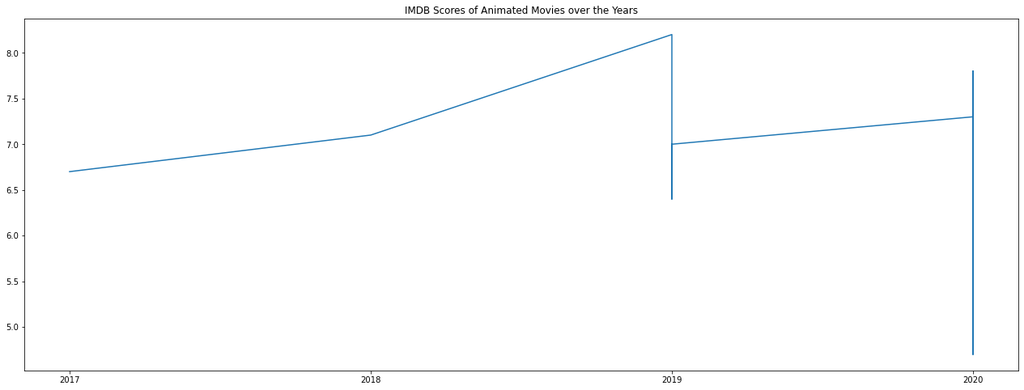

```python
# filtering out animated/anime movies

genre_animated=df[df['Genre'].str.contains("anime|animation", case=False)].sort_values(by="Release Year")

x=genre_animated["Release Year"]
y=genre_animated['IMDB Score']

# plotting the genre_filter in a line plot along with the years
g=plt.plot(x, y )
plt.title("IMDB Scores of Animated Movies over the Years")
fig = plt.gcf()
fig.set_size_inches(22, 8)
```

From this graph, we can see that animated movies have been doing quite well till 2019 but then there's a sudden drop but this drop could be caused by an outlier maybe. So overall, animated movies did pretty well so Netflix should continue to release more animated films.

#### Question 4

**How good did movies with language other than English did?**

Lastly, we will try to analyze that did non-English language movies good and should Netflix continue to release these films.

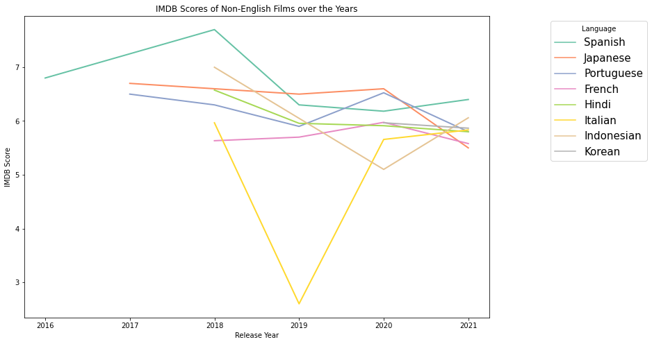

```python
# plotting the non-english films in a line plot along with the years
non_eng_movies=df[df["Language"].str.contains("English")==False]
non_eng=non_eng_movies.groupby('Language').filter(lambda x : len(x)>5).sort_values(by="Release Year")

non_eng_graph=sns.lineplot(data=non_eng, x=non_eng["Release Year"], y=non_eng['IMDB Score'], hue=non_eng["Language"], ci=None,linewidth = 2, palette="Set2")
non_eng_graph.legend(loc='upper right', bbox_to_anchor=(1.35, 1), prop={'size': 15}, title="Language")
non_eng_graph.set(title="IMDB Scores of Non-English Films over the Years")

fig = plt.gcf()
fig.set_size_inches(12, 8)
```

It seems like most of the non-English films have only a little bit of ups and downs based on their IMDB Scores but we can see a drastic fall in Italian and Indonesian movies so these 2 are not doing well for Netflix.

The films the most best are Spanish, Japanese and Portuguese films so it would be good for Netflix to continue releasing these films.

## Conclusion

This is the end of our exploratory analysis on the Netflix dataset. The main intention of this analysis was to get familiar with basic concepts of data analytics and visualization, how to ask and answer data-driven questions and to get a good grasp on python pandas, numpy, matplotlib and seaborn.

Some quite interesting insights were noted above along with visualizations. There are still so many more questions yet to be answered about this data but only a few have been answered for now to keep it brief.

This beginner project has been a great learning experience for me as it gave me an idea on how to get started with data analytics and how to solve data-driven problems. I expect a lot of mistakes made in it so feel free to point them out :)